```python
import pandas as pd
import numpy as np
import seaborn as sns
import matplotlib.pylab as plt
```

# **STEP1: Inspected csv_install using exploratory methods (e.g., .head(), .info())**

```python
df= pd.read_csv(r"C:\Users\falli\Downloads\Assessment 2 PROJECT Data Extraction, Normalization, and Reporting\starter_pack_AT2\starter_pack_AT2\sgu-solar-capacity-2011-to-present-and-totals.csv")


df.head()

# df.info()
# df.isnull().sum()
# df.describe()
# df.columns.tolist()
```

|  | Small Unit Postcode | Historic Total Rated Power Output In kW (2001 - 2010) | Jan 2011 - Rated Power Output In kW | Feb 2011 - Rated Power Output In kW | Mar 2011 - Rated Power Output In kW | Apr 2011 - Rated Power Output In kW | May 2011 - Rated Power Output In kW | Jun 2011 - Rated Power Output In kW | Jul 2011 - Rated Power Output In kW | Aug 2011 - Rated Power Output In kW | ... | Nov 2024 - Rated Power Output In kW | Dec 2024 - Rated Power Output In kW | Jan 2025 - Rated Power Output In kW | Feb 2025 - Rated Power Output In kW | Mar 2025 - Rated Power Output In kW | Apr 2025 - Rated Power Output In kW | May 2025 - Rated Power Output In kW | Jun 2025 - Rated Power Output In kW | Jul 2025 - Rated Power Output In kW | Total Rated Power Output In kW |
| --- | --- | --- | --- | --- | --- | --- | --- | --- | --- | --- | --- | --- | --- | --- | --- | --- | --- | --- | --- | --- | --- |
| 0 | 0 | 4.46 | 0.0 | 0.0 | 0.0 | 0.0 | 0.00 | 0.0 | 0.00 | 0.0 | ... | 0.000 | 0.0 | 0.0 | 0.0 | 0.0 | 0.00 | 0.0 | 0.00 | 0.0 | 4.460 |
| 1 | 200 | 0.08 | 0.0 | 0.0 | 0.0 | 0.0 | 0.00 | 0.0 | 0.00 | 0.0 | ... | 0.000 | 0.0 | 0.0 | 0.0 | 0.0 | 0.00 | 0.0 | 0.00 | 0.0 | 0.080 |
| 2 | 800 | 34.74 | 0.0 | 0.0 | 0.0 | 0.0 | 2.22 | 0.0 | 3.04 | 0.0 | ... | 123.045 | 0.0 | 0.0 | 0.0 | 274.5 | 99.88 | 0.0 | 164.23 | 0.0 | 4928.175 |
| 3 | 801 | 3.44 | 0.0 | 0.0 | 0.0 | 0.0 | 2.02 | 0.0 | 0.00 | 0.0 | ... | 0.000 | 0.0 | 0.0 | 0.0 | 0.0 | 0.00 | 0.0 | 0.00 | 0.0 | 386.598 |
| 4 | 803 | 0.00 | 0.0 | 0.0 | 0.0 | 0.0 | 0.00 | 0.0 | 0.00 | 0.0 | ... | 0.000 | 0.0 | 0.0 | 0.0 | 0.0 | 0.00 | 0.0 | 0.00 | 0.0 | 11.685 |

5 rows × 178 columns

# **STEP2: Renaming for clear vision**

## Manually renamed the first two columns to establish a clear structure, as they lacked common features with the rest of the dataset.

# **STEP3: Data Reshaping (Wide to Long Format) Converted the dataset from Wide Format to Long Format using the .melt() method.**

## To prepare the data for time-series visualization by defining id_vars, var_name (Month_year), and value_name (Capacity/Qty)

```python
#***STEP2: Renaming for clear vision
#STEP2-1: Manually rename the first two columns bcz no common feature with the rest.
df_power= df.rename(columns= {
    'Small Unit Postcode': 'Postcode',
    'Historic Total Rated Power Output In kW (2001 - 2010)': 'Hist_power_kW'
})

Month_year_power= {}
for col in df_power.columns:
    if '-' in col:
        new_name= col.split('-')[0]
        Month_year_power[col]= new_name
df_power= df_power.rename(columns= Month_year_power)

#***STEP3: For later visualisation need to unpivot the 'wide format' to 'long'
# Use method .melt() and decide whose are 'id_vars', 'var_name', 'value_name'

df_power_long= df_power.melt(id_vars=['Postcode','Hist_power_kW'],
                        var_name= 'Month_year',
                        value_name= 'Capacity_kW')
df_power_long
```

|  | Postcode | Hist_power_kW | Month_year | Capacity_kW |
| --- | --- | --- | --- | --- |
| 0 | 0 | 4.460 | Jan 2011 | 0.000 |
| 1 | 200 | 0.080 | Jan 2011 | 0.000 |
| 2 | 800 | 34.740 | Jan 2011 | 0.000 |
| 3 | 801 | 3.440 | Jan 2011 | 0.000 |
| 4 | 803 | 0.000 | Jan 2011 | 0.000 |
| ... | ... | ... | ... | ... |
| 494555 | 7469 | 2.100 | Total Rated Power Output In kW | 432.615 |
| 494556 | 7470 | 1.020 | Total Rated Power Output In kW | 408.562 |
| 494557 | 7802 | 2.450 | Total Rated Power Output In kW | 2.450 |
| 494558 | 8576 | 0.000 | Total Rated Power Output In kW | 6.840 |
| 494559 | 9729 | 0.875 | Total Rated Power Output In kW | 0.875 |

494560 rows × 4 columns

# **STEP4: Inspected another data for the 'csv_install' with methods**

# **STEP5: Renaming for clear vision**

# **STEP6: Repeated the inspection and .melt() process for the second installation dataset to ensure structural consistency.**

## Use method .melt() and decide whose are 'id_vars', 'var_name', 'value_name'

```python
df= pd.read_csv(r"C:\Users\falli\Downloads\Assessment 2 PROJECT Data Extraction, Normalization, and Reporting\starter_pack_AT2\starter_pack_AT2\sgu-solar-installations-2011-to-present-and-totals.csv")

#***STEP4: Observation the csv_install with methods
df.head()
# df.info()
# df.isnull().sum()
# df.describe()
df.columns.tolist()

#***STEP5: Renaming for clear vision
df_install= df.rename(columns={
    'Small Unit Installation Postcode':'Postcode',
    'Historic Total Installation Quantity (2001 - 2010)':'Hist_total_Qty'
})
month_year_install={}
for col in df_install.columns:
    if '-' in col:
        new_name= col.split('-')[0]
        month_year_install[col]= new_name
df_install= df_install.rename(columns= month_year_install)

#***STEP6: For later visualisation need to unpivot the 'wide format' to 'long'
# Use method .melt() and decide whose are 'id_vars', 'var_name', 'value_name'
df_install_long= df_install.melt(id_vars= ['Postcode','Hist_total_Qty'],
                                 var_name= 'Month_year',
                                 value_name= 'Capacity_Qty')
df_install_long
```

|  | Postcode | Hist_total_Qty | Month_year | Capacity_Qty |
| --- | --- | --- | --- | --- |
| 0 | 0 | 4 | Jan 2011 | 0 |
| 1 | 200 | 1 | Jan 2011 | 0 |
| 2 | 800 | 7 | Jan 2011 | 0 |
| 3 | 801 | 2 | Jan 2011 | 0 |
| 4 | 803 | 0 | Jan 2011 | 0 |
| ... | ... | ... | ... | ... |
| 494555 | 7469 | 2 | Total Installation Quantity | 78 |
| 494556 | 7470 | 1 | Total Installation Quantity | 74 |
| 494557 | 7802 | 1 | Total Installation Quantity | 1 |
| 494558 | 8576 | 0 | Total Installation Quantity | 2 |
| 494559 | 9729 | 1 | Total Installation Quantity | 1 |

494560 rows × 4 columns

# **STEP7: Table merging the two columns 'df_power_long' and 'de_install_long'**

## Using a Composite Key (Postcode and Month_year).'

```python
#***STEP7: Merging two columns df_power_long and de_install_long
# Join key by 'Postcode' and 'Month_year'

df_power_install_merge= pd.merge(
    left= df_power_long,
    right= df_install_long,
    on= ['Postcode', 'Month_year'],
    how= 'inner'
)

df_power_install_merge.head()
```

|  | Postcode | Hist_power_kW | Month_year | Capacity_kW | Hist_total_Qty | Capacity_Qty |
| --- | --- | --- | --- | --- | --- | --- |
| 0 | 0 | 4.46 | Jan 2011 | 0.0 | 4 | 0 |
| 1 | 200 | 0.08 | Jan 2011 | 0.0 | 1 | 0 |
| 2 | 800 | 34.74 | Jan 2011 | 0.0 | 7 | 0 |
| 3 | 801 | 3.44 | Jan 2011 | 0.0 | 2 | 0 |
| 4 | 803 | 0.00 | Jan 2011 | 0.0 | 0 | 0 |

# **STEP8: Identified and dropped 'historic power' and 'historic qty' columns.**

## Considering the 'historic power' & 'historic qty' are total summary which affect trend chart, so I try to drop these two columns.

## These are summary totals that would distort the trend analysis and lead to double-counting in charts.

```python
#***STEP8: Considering the 'historic power' & 'historic qty' are total summary which affect trend chart, so I try to drop these two columns.

df_power_install_merge_drop= df_power_install_merge.drop(
    columns= ['Hist_power_kW','Hist_total_Qty'],
    inplace= False) #Not sure if these data can be needed for later so I decide to keep them with the previous vision of 'df_pwer_install_merge'

df_power_install_merge_drop.dtypes
```

```
Postcode          int64
Month_year       object
Capacity_kW     float64
Capacity_Qty      int64
dtype: object
```

# **Designed Five Questions:**

## **- 1. How's the time trend shown of solar capacity grown from 2011 to 2021?**

## **- 2. What's the total capacity per person in each state?**

## **- 3. Which state has the highest market potential (uninstalled population)?**

## **- 4. What percentage of each state's capacity comes from its Top 10 postcodes?**

## **- 5. Has the per-person solar capacity gap between Summer and Winter widened from 2011 to 2021??**

# **Data Sourcing**

## **- External Source from Kaggle dataset:**

## Verified the column 'Tot_P_P' using the 'Metadata_2021_GCP_DataPack_R1'.

## **- Definition:**

## Confirmed that 'Tot_P_P' represents 'Total Persons' (population count) for each postcode.

## **- Objective:**

## Extracted and cleaned the population data to merge with the existing solar dataset (df_power_install_merge_drop). This allows for per-capita analysis and market penetration calculations.

```python
df_POA= pd.read_csv(r"C:\Users\falli\Downloads\Assessment 2 PROJECT Data Extraction, Normalization, and Reporting\archive\2021 Census GCP All Geographies for AUS\POA\AUS\2021Census_G01_AUST_POA.csv")
df_POA.head()
df_POA.info()
df_POA.dtypes
df.shape
```

```
<class 'pandas.core.frame.DataFrame'>
RangeIndex: 2643 entries, 0 to 2642
Columns: 109 entries, POA_CODE_2021 to Count_Persons_other_dwgs_P
dtypes: int64(108), object(1)
memory usage: 2.2+ MB
```

```
(2810, 178)
```

# **STEP9: Feature Selection & Metadata Preparation.**

## Extract the column 'Tot_P_P' and keep column 'POA_CODE_2021' as I need this for the Key.

## Standardized column names to Postcode and Total_person for consistent joining with the primary solar dataset.

```python
# STEP9 Extract the column 'Tot_P_P' and keep column 'POA_CODE_2021' as I need this for the Key.
# 9-1 Rename the POA_CODE_2021 & Tot_P_P as 'Postcode' (my key) &'Total_person'
df_POA_extract= df_POA.rename(columns= {
    'POA_CODE_2021':'Postcode',
    'Tot_P_P':'Total_person'})

df_POA_extract.head()

# 9-2 Removing the POA in postcode
df_POA_extract['Postcode']= df_POA_extract['Postcode'].str.replace('POA','')
df_POA_extract['Postcode']= df_POA_extract['Postcode'].astype(int)
df_POA_extract.dtypes

# 9-3 Extract the columns only 'Postcode' & 'Total_person'

df_POA_extract= df_POA_extract[['Postcode','Total_person']]
df_POA_extract.head()
```

|  | Postcode | Total_person |
| --- | --- | --- |
| 0 | 2000 | 27936 |
| 1 | 2007 | 7410 |
| 2 | 2008 | 10400 |
| 3 | 2009 | 12658 |
| 4 | 2010 | 26443 |

# **STEP:10 Identifying Missing Context merge to the TWO files 'df_power_install_merge_drop' & 'df_POA_extract'**

```python
# STEP:10 merge to the TWO files df_power_install_merge_drop & df_POA_extract

df_power_install_POA= df_power_install_merge_drop.merge(
    df_POA_extract,
    on= 'Postcode',
    how= 'inner'
)

df_power_install_POA.head()
```

|  | Postcode | Month_year | Capacity_kW | Capacity_Qty | Total_person |
| --- | --- | --- | --- | --- | --- |
| 0 | 800 | Jan 2011 | 0.00 | 0 | 7149 |
| 1 | 810 | Jan 2011 | 3.02 | 2 | 34330 |
| 2 | 812 | Jan 2011 | 3.00 | 1 | 18634 |
| 3 | 820 | Jan 2011 | 0.00 | 0 | 19920 |
| 4 | 822 | Jan 2011 | 0.00 | 0 | 25304 |

# **STEP:11 Found out has no state and territory so I need to try to see other files and add a join key**

## Data Mapping & Integration: To ensure spatial accuracy, the 2021Census_geog_desc_1st_release metadata file was utilized. Specifically, Sheet 4 (POA) was used to verify the correspondence between Postcode Areas and official geographic descriptors. This mapping process was critical for the seamless integration of ARENA’s solar installation data with the 2021 Census population datasets.

```python
#STEP: 11 Found out no state and territory so try to see another file
file_path= (r"C:\Users\falli\Downloads\Assessment 2 PROJECT Data Extraction, Normalization, and Reporting\archive\Metadata\2021Census_geog_desc_1st_release.xlsx")
df_mega= pd.read_excel(file_path, sheet_name=3)
df_mega.head()
df_mega.dtypes
print(df_mega.iloc[1186])
```

```
ASGS_Structure            POA
Census_Code_2021      POA2448
AGSS_Code_2021           2448
Census_Name_2021    2448, NSW
Area sqkm            115.0676
Name: 1186, dtype: object
```

# **STEP12: Data Discovery & Bridge Key Selection**

```python
df_poa_filter= df_mega[df_mega['ASGS_Structure']== 'POA'].copy()
df_poa_final= df_poa_filter[['AGSS_Code_2021','Census_Name_2021']]

df_poa_final.head()
```

|  | AGSS_Code_2021 | Census_Name_2021 |
| --- | --- | --- |
| 1186 | 2448 | 2448, NSW |
| 1187 | 2000 | 2000, NSW |
| 1188 | 2007 | 2007, NSW |
| 1189 | 2008 | 2008, NSW |
| 1190 | 2009 | 2009, NSW |

# **STEP13: Data Integration Finalized the reference table as df_poa_final**

```python
df_poa_final= df_poa_final.rename(columns={
    'AGSS_Code_2021':'Postcode',
    'Census_Name_2021':'Postcode_state'
})
df_poa_final.head()
```

|  | Postcode | Postcode_state |
| --- | --- | --- |
| 1186 | 2448 | 2448, NSW |
| 1187 | 2000 | 2000, NSW |
| 1188 | 2007 | 2007, NSW |
| 1189 | 2008 | 2008, NSW |
| 1190 | 2009 | 2009, NSW |

# **STEP14: Performed an Inner Join between the state reference table (df_poa_final) and the primary solar dataset (df_power_install_POA).**

```python
df_power_install_POA_state= df_poa_final.merge(
    df_power_install_POA,
    on= 'Postcode',
    how= 'inner'
)
df_power_install_POA_state.head(-5)
```

|  | Postcode | Postcode_state | Month_year | Capacity_kW | Capacity_Qty | Total_person |
| --- | --- | --- | --- | --- | --- | --- |
| 0 | 2448 | 2448, NSW | Jan 2011 | 51.915 | 22 | 9618 |
| 1 | 2448 | 2448, NSW | Feb 2011 | 36.665 | 14 | 9618 |
| 2 | 2448 | 2448, NSW | Mar 2011 | 58.590 | 19 | 9618 |
| 3 | 2448 | 2448, NSW | Apr 2011 | 31.780 | 10 | 9618 |
| 4 | 2448 | 2448, NSW | May 2011 | 32.830 | 16 | 9618 |
| ... | ... | ... | ... | ... | ... | ... |
| 460940 | 6798 | 6798, OT | Oct 2024 | 0.000 | 0 | 1692 |
| 460941 | 6798 | 6798, OT | Nov 2024 | 0.000 | 0 | 1692 |
| 460942 | 6798 | 6798, OT | Dec 2024 | 0.000 | 0 | 1692 |
| 460943 | 6798 | 6798, OT | Jan 2025 | 0.000 | 0 | 1692 |
| 460944 | 6798 | 6798, OT | Feb 2025 | 0.000 | 0 | 1692 |

460945 rows × 6 columns

# **STEP15: Feature Engineering & Cleaning the new 'State' column successfully added.**

```python
df_power_install_POA_state['State'] = df_power_install_POA_state['Postcode_state'].str.split(',').str[1].str.strip()
df_power_install_POA_state.head(-5)
```

|  | Postcode | Postcode_state | Month_year | Capacity_kW | Capacity_Qty | Total_person | State |
| --- | --- | --- | --- | --- | --- | --- | --- |
| 0 | 2448 | 2448, NSW | Jan 2011 | 51.915 | 22 | 9618 | NSW |
| 1 | 2448 | 2448, NSW | Feb 2011 | 36.665 | 14 | 9618 | NSW |
| 2 | 2448 | 2448, NSW | Mar 2011 | 58.590 | 19 | 9618 | NSW |
| 3 | 2448 | 2448, NSW | Apr 2011 | 31.780 | 10 | 9618 | NSW |
| 4 | 2448 | 2448, NSW | May 2011 | 32.830 | 16 | 9618 | NSW |
| ... | ... | ... | ... | ... | ... | ... | ... |
| 460940 | 6798 | 6798, OT | Oct 2024 | 0.000 | 0 | 1692 | OT |
| 460941 | 6798 | 6798, OT | Nov 2024 | 0.000 | 0 | 1692 | OT |
| 460942 | 6798 | 6798, OT | Dec 2024 | 0.000 | 0 | 1692 | OT |
| 460943 | 6798 | 6798, OT | Jan 2025 | 0.000 | 0 | 1692 | OT |
| 460944 | 6798 | 6798, OT | Feb 2025 | 0.000 | 0 | 1692 | OT |

460945 rows × 7 columns

# **STEP16: Seems like the 'Postcode_state' is unnecessary so I decide to drop.**

```python
df_power_install_POA_state_final= df_power_install_POA_state.drop(
    columns= ['Postcode_state'],
    inplace= False
)
df_power_install_POA_state_final.head()
```

|  | Postcode | Month_year | Capacity_kW | Capacity_Qty | Total_person | State |
| --- | --- | --- | --- | --- | --- | --- |
| 0 | 2448 | Jan 2011 | 51.915 | 22 | 9618 | NSW |
| 1 | 2448 | Feb 2011 | 36.665 | 14 | 9618 | NSW |
| 2 | 2448 | Mar 2011 | 58.590 | 19 | 9618 | NSW |
| 3 | 2448 | Apr 2011 | 31.780 | 10 | 9618 | NSW |
| 4 | 2448 | May 2011 | 32.830 | 16 | 9618 | NSW |

# **STEP17: Time-Series Preparation. As above I designed my questions, I found out I need to do some more things:**

## - To enable time-series visualization and trend analysis.

## - Converted Month_year column into **Standard Datetime format** using Pandas.

```python
# I would like to see the visualization yearly and follow the time trend so I need to exchange the 'Month_year' to Datetime format.
df_power_install_POA_state_final['Date']= pd.to_datetime(
    df_power_install_POA_state_final['Month_year'])
df_power_install_POA_state_final.head()

# For showing my graphic in year so I need to extract year & month & period
df_power_install_POA_state_final['Year']= df_power_install_POA_state_final['Date'].dt.year
df_power_install_POA_state_final['Month']= df_power_install_POA_state_final['Date'].dt.month
df_power_install_POA_state_final['Year_Month']= df_power_install_POA_state_final['Date'].dt.to_period('M')

# I don't like the 'Date' bcz the original datasets has no particularly date.
df_power_install_POA_state_final.drop(columns= ['Date','Month_year'], inplace= True)

df_power_install_POA_state_final.info()
df_power_install_POA_state_final.head()
```

```
<class 'pandas.core.frame.DataFrame'>
RangeIndex: 460950 entries, 0 to 460949
Data columns (total 8 columns):
 #   Column        Non-Null Count   Dtype
---  ------        --------------   -----
 0   Postcode      460950 non-null  object
 1   Capacity_kW   460950 non-null  float64
 2   Capacity_Qty  460950 non-null  int64
 3   Total_person  460950 non-null  int64
 4   State         458325 non-null  object
 5   Year          460950 non-null  int32
 6   Month         460950 non-null  int32
 7   Year_Month    460950 non-null  period[M]
dtypes: float64(1), int32(2), int64(2), object(2), period[M](1)
memory usage: 24.6+ MB
```

|  | Postcode | Capacity_kW | Capacity_Qty | Total_person | State | Year | Month | Year_Month |
| --- | --- | --- | --- | --- | --- | --- | --- | --- |
| 0 | 2448 | 51.915 | 22 | 9618 | NSW | 2011 | 1 | 2011-01 |
| 1 | 2448 | 36.665 | 14 | 9618 | NSW | 2011 | 2 | 2011-02 |
| 2 | 2448 | 58.590 | 19 | 9618 | NSW | 2011 | 3 | 2011-03 |
| 3 | 2448 | 31.780 | 10 | 9618 | NSW | 2011 | 4 | 2011-04 |
| 4 | 2448 | 32.830 | 16 | 9618 | NSW | 2011 | 5 | 2011-05 |

# **Questions 1. National Growth Trend:**

# **'How's the time trend shown of solar capacity grown from 2011 to 2021?'**

```python
# Questions 1. How's the time trend shown of solar capacity grown from 2011 to 2021?
filter_year= df_power_install_POA_state_final.query('2011 <= Year <= 2021')
year_state_cap= filter_year[['Year', 'State', 'Postcode','Capacity_kW']].drop_duplicates()

yearly_trend= year_state_cap.groupby('Year')['Capacity_kW'].sum().reset_index()
yearly_trend
```

|  | Year | Capacity_kW |
| --- | --- | --- |
| 0 | 2011 | 870358.373 |
| 1 | 2012 | 1033409.222 |
| 2 | 2013 | 788035.204 |
| 3 | 2014 | 794320.126 |
| 4 | 2015 | 700804.840 |
| 5 | 2016 | 745222.226 |
| 6 | 2017 | 1117600.803 |
| 7 | 2018 | 1615102.308 |
| 8 | 2019 | 2162043.827 |
| 9 | 2020 | 2959799.498 |
| 10 | 2021 | 3188157.674 |

## **Q1 Visualization: Line chart**

### **- Insight:**

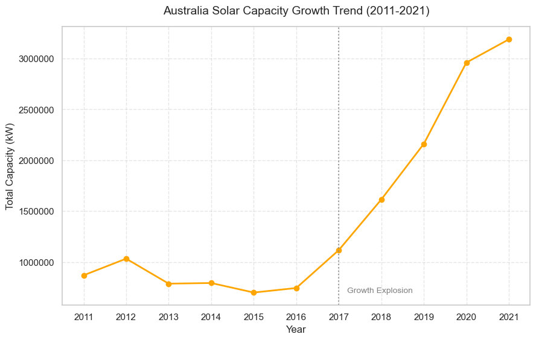

```python
# 1. Line chart: Used to visualize sequential values and identify growth trends.
plt.figure(figsize= (10,6))
plt.plot(yearly_trend['Year'], yearly_trend['Capacity_kW'],
         marker='o',
         linewidth= 2,
         color= 'orange',
         label= 'Total Capacity')

# 2. Configure x-axis to display every year from 2011 to 2021
plt.xticks(range(2011, 2022))

# 3. Title & labels
plt.title('Australia Solar Capacity Growth Trend (2011-2021)', fontsize= 14, pad= 15)
plt.xlabel('Year', fontsize= 12)
plt.ylabel('Total Capacity (kW)', fontsize= 12)

# 4. Formatting: Prevent scientific notation on Y-axis and add grid
plt.ticklabel_format(style='plain', axis='y')
plt.grid(True, linestyle='--', alpha=0.5)

# 5. Highlight 2017 as a major market turning point
plt.axvline(x=2017, color='gray', linestyle=':', alpha=0.8)
plt.text(2017.2, yearly_trend['Capacity_kW'].min(), 'Growth Explosion', color='gray', fontsize=10)

plt.show()
```

## **Q1 How's the time trend shown of solar capacity grown from 2011 to 2021?**

### - **Objective:**

### To visualize the historical growth of solar capacity in Australia from 2011 to 2021 and identify significant market shifts.

### - **Key Finding:**

### The solar market experienced a "warm-up" phase between 2011 and 2016, followed by a massive explosion in growth starting in 2017.

### - **Business Insight:**

### The post-2017 surge indicates that solar energy has moved from a niche technology to a mainstream energy source in Australia, likely driven by **falling hardware costs** and **supportive government policies**.

# **Question 2. Leading State by Per-Capita Capacity:**

# **'What's the total capacity by per person in each state?'**

```python
# Questions 2.What's the total capacity by per person in each state?
# Since the 'Total_person' column is repeated for each record in the same postcode,
# I need to handle the values carefully to avoid overcounting the population.

# Step A. Calculate total capacity (kW) per state
state_capacity= df_power_install_POA_state_final.groupby('State')['Capacity_kW'].sum().reset_index()
state_capacity.head()
# Step B. Process population data
# 1. Remove duplicate population records to get a unique total for each postcode
postcode_pop= df_power_install_POA_state_final[['Postcode','State','Total_person']].drop_duplicates()
postcode_pop.head()

# 2. Sum the unique postcode populations to get the actual state tota
state_population= postcode_pop.groupby('State')['Total_person'].sum().reset_index()
state_population.head(10)


# # Step C. Calculate Capacity per Person (kW per person)
# 1. Merge state capacity and state population into a single dataframe
df_per_capita= pd.merge(state_capacity,state_population, on= 'State')
df_per_capita.head()

# 2. Calculating the power producing per person in each state.
df_per_capita['kW_per_person']= df_per_capita['Capacity_kW']/ df_per_capita['Total_person']
df_per_capita.head()

# 3. Sorting the ranking from highest to lowest
df_per_capita= df_per_capita.sort_values('kW_per_person', ascending= False)
df_per_capita.head(10)
```

|  | State | Capacity_kW | Total_person | kW_per_person |
| --- | --- | --- | --- | --- |
| 5 | SA | 2676191.864 | 1775803 | 1.507032 |
| 4 | QLD | 7082297.909 | 5112066 | 1.385408 |
| 8 | WA | 2919835.920 | 2649645 | 1.101972 |
| 3 | OT | 4514.320 | 4473 | 1.009238 |
| 0 | ACT | 410027.138 | 416065 | 0.985488 |
| 2 | NT | 198382.591 | 217370 | 0.912649 |
| 1 | NSW | 7259390.337 | 7963452 | 0.911588 |
| 7 | VIC | 5201318.110 | 6471166 | 0.803768 |
| 6 | TAS | 368621.186 | 556113 | 0.662853 |

## **Comparison of visualization libraries:**

## - 1. Pandas: Quickest way to plot directly from a DataFrame.

## - 2. Matplotlib: Offers the most control over specific details (e.g., barh indexing).

## - 3. Seaborn: Best for aesthetics and professional "viridis" color palettes.

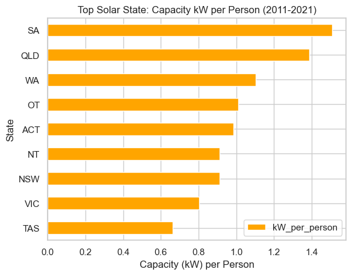

```python
# Question 2. Visualization (pandas)
df_per_capita.iloc[::-1].plot(
    kind= 'barh',
    x= 'State',
    y= 'kW_per_person',
    color= 'orange',
)

plt.title('Top Solar State: Capacity kW per Person (2011-2021)')
plt.xlabel('Capacity (kW) per Person')
plt.ylabel('State')
plt.show()
```

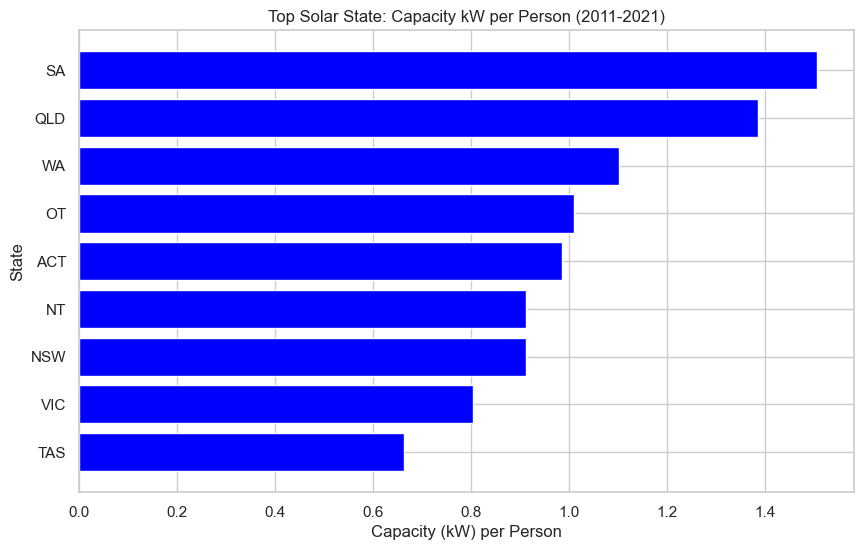

```python
# Question 2. Visualization (Matplotlib)
plt.figure(figsize= (10,6))

plt.barh(df_per_capita.iloc[::-1]['State'],df_per_capita.iloc[::-1]['kW_per_person'], color= 'blue')
plt.title('Top Solar State: Capacity kW per Person (2011-2021)')
plt.xlabel('Capacity (kW) per Person')
plt.ylabel('State')
plt.show()
```

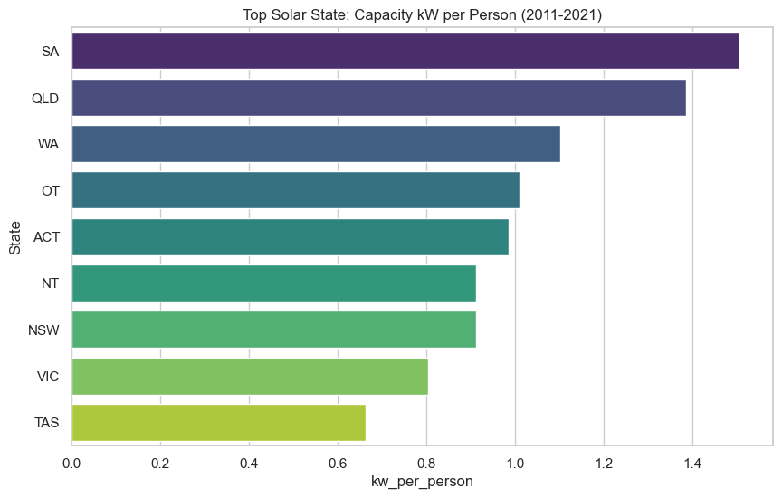

```python
# Question 2. Visualization (Seaborn)
sns.set_theme(style= 'whitegrid')

plt.figure(figsize= (10,6))

sns.barplot(
    data= df_per_capita,
    x= 'kW_per_person',
    y= 'State',
    palette= 'viridis'
)

plt.title('Top Solar State: Capacity kW per Person (2011-2021)')
plt.xlabel('kw_per_person')
plt.ylabel('State')
plt.show()
```

## **Q2 What's the total capacity by per person in each state?**

### - **Objective:**

### To compare the solar performance of states on a "per-person" basis, ensuring a fair comparison regardless of population size.

### - **Key Finding:**

### South Australia (SA) consistently leads the nation in solar capacity per capita, significantly outperforming more populous states like NSW and VIC.

### - **Business Insight:**

### High per-capita figures in SA suggest a very mature consumer market with high household adoption rates. For businesses, this indicates a highly educated but potentially competitive market compared to states with lower per-capita figures.

# **Questions 3. Market Potential Analysis:**

# **'Which state has the highest market potential (uninstalled population)?'**

```python
# Questions 3.Which state has the highest market potential (uninstalled population)?
# 1. Get the total installation in each state in latest data year 2021
last_year= filter_year[filter_year['Year']== 2021]
state_installs= filter_year.groupby('State')['Capacity_Qty'].sum().reset_index()
state_installs.columns= ['State','Total_Installations']

# 2. combining the total installs and total person
df_potential= pd.merge(state_installs, state_population, on= 'State')
df_potential

# 3. Calculating potential rate in percentage
df_potential['Penetration_Rate %']= (df_potential['Total_Installations'])/ df_potential['Total_person'] *100

# 4.sorting ascending
df_potential= df_potential.sort_values('Penetration_Rate %', ascending= True)
df_potential
```

|  | State | Total_Installations | Total_person | Penetration_Rate % |
| --- | --- | --- | --- | --- |
| 6 | TAS | 40579 | 556113 | 7.296898 |
| 0 | ACT | 31481 | 416065 | 7.566366 |
| 3 | OT | 366 | 4473 | 8.182428 |
| 1 | NSW | 657489 | 7963452 | 8.256332 |
| 7 | VIC | 551292 | 6471166 | 8.519207 |
| 2 | NT | 18624 | 217370 | 8.567880 |
| 8 | WA | 382313 | 2649645 | 14.428839 |
| 4 | QLD | 775065 | 5112066 | 15.161483 |
| 5 | SA | 308539 | 1775803 | 17.374619 |

## **Q3 Visualization: Bar Chart**

### A ranked bar chart was selected to compare solar penetration across different states.

### - **Purpose:**

### This visualization highlights the percentage of the population that has adopted solar energy in each state, providing a clear benchmark against the National Average (red dashed line).

### - **Insight:**

### While larger states have higher total capacity, this chart reveals that their market penetration is relatively low. This indicates a significant "Uninstalled Population" and represents high growth potential for future solar expansion in states like NSW and VIC.

[figure not shown]

```python
plt.figure(figsize=(10,7))
bars= plt.bar(df_potential['State'], df_potential['Penetration_Rate %'], color= 'green')

# 1. Adjusting y-axis limit and ensure the marking percentage not reach the title banner
plt.ylim(0,df_potential['Penetration_Rate %'].max()* 1.2)
# Axis Horizontal Line
plt.axhline(y= df_potential['Penetration_Rate %'].mean(), color='red', linestyle='--', label='National Avg')


# 2. Data Readability: Glamorizing labels Horizontal Alignment(ha='center') and decrease font size
for i, val in enumerate(df_potential['Penetration_Rate %']):
    plt.text(i,val +(df_potential['Penetration_Rate %'].max()* 0.02),
             f'{val:.1f}%',
             ha= 'center',
             fontsize= 10,
             fontweight= 'bold',
             color= 'green')
plt.title('Solar Penetration Rate by State(2021)', fontsize= 14, pad= 20)# adding pad to move the title up
plt.ylabel('Penetration of Population with Solar (%)', fontsize= 12)
plt.xlabel('State', fontsize= 12)
plt.legend(loc= 'upper left')
plt.grid(axis= 'y', linestyle= '--', alpha= 0.4)

plt.tight_layout()
plt.show()
```

## **Q3 Which state has the highest market potential (uninstalled population)?**

### - **Objective:**

### Identify states with the highest growth potential by analyzing "Penetration Rate" (Solar installations per capita).

### - **Key Finding:**

### States with lower penetration rates (e.g., NSW, VIC) represent "Blue Ocean" markets. Despite having high total capacity, their large populations mean many households have yet to adopt solar.

### - **Business Insight:**

### Marketing efforts should prioritize **low-penetration** states to capture the uninstalled population.

# **Question 4. Market Concentration:**

# **'What percentage of each state's capacity comes from its Top 10 postcodes?'**

```python
# Question 4.Market Concentration: What percentage of each state's capacity comes from its Top 10 postcodes
# 1. calculating top 10 in each state
postcode_totals= filter_year.groupby(['State', 'Postcode'])['Capacity_kW'].sum().reset_index()
top_10_postcodes= postcode_totals.groupby('State').apply(lambda x: x.nlargest(10, 'Capacity_kW')).reset_index(drop=True)

# 2. calculating the total capacity in each state
top10_sum = top_10_postcodes.groupby('State')['Capacity_kW'].sum().reset_index()


# 3. Combine the tow columns on state
df_q4= pd.merge(top10_sum, state_total, on='State', suffixes=('_Top10', '_Total'))
df_q4['Concentration_Rate']= (df_q4['Capacity_kW_Top10'] / df_q4['Capacity_kW_Total']) * 100

# 4. ascending the high rate on the top
df_q4= df_q4.sort_values('Concentration_Rate', ascending=False)
df_q4
```

|  | State | Capacity_kW_Top10 | Capacity_kW_Total | Concentration_Rate |
| --- | --- | --- | --- | --- |
| 3 | OT | 1891.170 | 1891.170 | 100.000000 |
| 2 | NT | 122132.937 | 143764.586 | 84.953423 |
| 0 | ACT | 139453.394 | 196766.253 | 70.872618 |
| 6 | TAS | 74007.921 | 211952.518 | 34.917217 |
| 8 | WA | 492881.085 | 1942433.803 | 25.374408 |
| 4 | QLD | 676256.131 | 4370777.797 | 15.472215 |
| 7 | VIC | 490349.826 | 3169647.064 | 15.470171 |
| 5 | SA | 257072.422 | 1776450.477 | 14.471128 |
| 1 | NSW | 449487.161 | 4039931.913 | 11.126107 |

## **Q4 Visualization: Bar chart**

### Sorted by concentration percentage:

### - **Purpose:**

### To evaluate the distribution risk within each state by measuring how much of the total capacity is contributed by the Top 10 postcodes.

### - **Insight:**

### Highly Concentrated Markets (e.g., NT, ACT): A small number of postcodes dominate the solar output, indicating that growth is driven by specific regional hubs or large-scale projects.

[figure not shown]

```python
plt.figure(figsize=(10,7))
# 1. Plotting the Bar Chart
plt.bar(df_q4['State'], df_q4['Concentration_Rate'], color= 'blue')

# 2. Set Y-axis limit higher to provide "breathing room" for labels
plt.ylim(0, df_q4['Concentration_Rate'].max()* 1.2)

# 3. Add a red dashed line to represent the National Average for comparison
avg_concentration= df_q4['Concentration_Rate']. mean()
plt.axhline(y= avg_concentration, color= 'red', linestyle= '--', label= f'National Avg ({avg_concentration:.1f}%)')

# 4. Data Labeling Loop: Automatically place percentages above each bar
gap= df_q4['Concentration_Rate'].max()* 0.02
for i, val in enumerate(df_q4['Concentration_Rate']):
    plt.text(x= i,
             y= val + gap,
             s= f'{val:.1f}%',
             ha= 'center',
             fontweight= 'bold',
             color= 'darkblue')

# 5. Formatting Title and Axis Labels
plt.title('Market Concentration: Top 10 Postcodes Share of State Total (2021)', fontsize= 14, pad= 15)
plt.ylabel('Share of State Total (%)', fontsize=12)
plt.xlabel('State', fontsize=12)

# 6. Final Touches
plt.legend(loc= 'upper right')
plt.grid(axis= 'y', linestyle= '--', alpha= 0.3)
plt.tight_layout()

plt.show()
```

## **Q4 What percentage of each state's capacity comes from its Top 10 postcodes?**

### - **Objective:**

### Measure how much the top 10 postcodes contribute to each state's total solar capacity.

### - **Key Finding:**

### Higher percentages (e.g., NT, ACT) indicate market "clustering," where solar adoption is heavily reliant on specific regions.

### Lower percentages (e.g., NSW, QLD) suggest a "decentralized" market where solar is evenly distributed across the state.

### - **Business Insight:**

### Decentralized markets are tougher because the growth comes from everywhere, not just a few spots. It shows that solar has truly gone mainstream.

### In short, the growth in NSW is spread across many communities rather than just a few 'hotspots.' This makes the market more stable and proves that solar is now a mainstream choice for everyday Australians.